# Simulación de tiempos de llegada

## Datos

Utilizaremos los datos de la elección presidencial de 2018.

- Muestra seleccionada para el conteo rápido.
- Remesas de la muestra seleccionada, hasta media noche.
- Tabla de cómputos distritales por casilla

## Idea para simulación

1. Construir para cada estado un modelo para los tiempos de llegada de las casillas según los datos de remesas, en términos de lista nominal, tipo de casilla, porcentaje de votos obtenidos para los candidatos y otras variables.
2. Seleccionar una muestra nueva a partir de la tabla de conteos distritales y según el diseño.
3. Simular tiempos de llegada según el modelos construido en 1)

Con estas simulaciones podemos entonces

4. Evaluar propiedades de estimadores (por ejempĺo cobertura para intervalos, o sesgo para estimadores puntuales) dependiendo de la hora de corte, o cortes basados en % de casillas recibidas en las remesas simuladas.

En esta versión, consideramos la estimación de proporción de votos para un candidato usando el estimador de razón combinado bajo muestreo estratificado según distrito federal.

## Modelos de tiempo de llegada

```r
estados %>% sort
```

```
##  [1] "BC"   "BCS"  "CAMP" "CHIH" "COL"  "GRO"  "MICH" "NAY"  "NL"   "QRO"
## [11] "SIN"  "SLP"  "SON"  "TLAX" "ZAC"
```

```r
length(estados)
```

```
## [1] 15
```

Los coeficientes y escalas para cada estado son:

```r
reg_2 %>% tidy() %>%
  mutate(across(is.numeric, ~round(., 3))) %>%
  DT::datatable()
```

|  | term | estimate | std.error | statistic | p.value |
| --- | --- | --- | --- | --- | --- |
| 1 | (Intercept) | 0.542 | 0.331 | 1.635 | 0.102 |
| 2 | ln_log_c | 0.296 | 0.078 | 3.791 | 0 |
| 3 | tipo_casillaC | 0.002 | 0.028 | 0.064 | 0.949 |
| 4 | tipo_casillaE | 0.013 | 0.062 | 0.204 | 0.838 |
| 5 | tipo_casillaS | 1.902 | 0.37 | 5.14 | 0 |
| 6 | tipo_seccion2 | -0.012 | 0.04 | -0.293 | 0.77 |
| 7 | tipo_seccion3 | 0.243 | 0.043 | 5.647 | 0 |
| 8 | state_abbrBC:log(1 + RAC_1/(TOTAL_VOTOS_CALCULADOS + 1)) | -1.369 | 0.704 | -1.945 | 0.052 |
| 9 | state_abbrBCS:log(1 + RAC_1/(TOTAL_VOTOS_CALCULADOS + 1)) | -0.329 | 0.957 | -0.344 | 0.731 |
| 10 | state_abbrCAMP:log(1 + RAC_1/(TOTAL_VOTOS_CALCULADOS + 1)) | 1.393 | 1.449 | 0.961 | 0.336 |

[output cut: 71 more lines]

```r
reg_2$scale
```

```
##        BC       BCS      CAMP      CHIH       COL       GRO      MICH       NAY
## 0.4209161 0.2503877 0.3131167 0.3689343 0.2663032 0.4355178 0.3205568 0.4966274
##        NL       QRO       SIN       SLP       SON      TLAX       ZAC
## 0.3706638 0.2959815 0.7234662 0.3541177 0.3960206 0.1892640 0.4988575
```

```r
reg_2 %>% summary()
```

```
##
## Call:
## survreg(formula = Surv(tiempo_huso, status) ~ 1 + ln_log_c +
##     tipo_casilla + state_abbr:log(1 + RAC_1/(TOTAL_VOTOS_CALCULADOS +
##     1)) + state_abbr:log(1 + AMLO_1/(TOTAL_VOTOS_CALCULADOS +
##     1)) + state_abbr:log(1 + JAMK_1/(TOTAL_VOTOS_CALCULADOS +
##     1)) + state_abbr:ln_log_c + tipo_seccion + strata(state_abbr),
##     data = llegadas_tbl_2, dist = "loglogistic", control = survreg.control(maxiter = 5000))
##                                                                Value Std. Error
## (Intercept)                                                  0.54165    0.33134
## ln_log_c                                                     0.29573    0.07801
## tipo_casillaC                                                0.00177    0.02765
## tipo_casillaE                                                0.01272    0.06240
## tipo_casillaS                                                1.90239    0.37010
## tipo_seccion2                                               -0.01173    0.04008
## tipo_seccion3                                                0.24303    0.04303
## state_abbrBC:log(1 + RAC_1/(TOTAL_VOTOS_CALCULADOS + 1))    -1.36912    0.70385
## state_abbrBCS:log(1 + RAC_1/(TOTAL_VOTOS_CALCULADOS + 1))   -0.32940    0.95750
## state_abbrCAMP:log(1 + RAC_1/(TOTAL_VOTOS_CALCULADOS + 1))   1.39295    1.44877
## state_abbrCHIH:log(1 + RAC_1/(TOTAL_VOTOS_CALCULADOS + 1))  -1.19709    0.52646
## state_abbrCOL:log(1 + RAC_1/(TOTAL_VOTOS_CALCULADOS + 1))   -3.49123    1.33798
## state_abbrGRO:log(1 + RAC_1/(TOTAL_VOTOS_CALCULADOS + 1))    1.93385    0.69261
## state_abbrMICH:log(1 + RAC_1/(TOTAL_VOTOS_CALCULADOS + 1))   0.49092    0.53205
## state_abbrNAY:log(1 + RAC_1/(TOTAL_VOTOS_CALCULADOS + 1))   -2.23863    1.44900
## state_abbrNL:log(1 + RAC_1/(TOTAL_VOTOS_CALCULADOS + 1))     1.00843    0.48691
## state_abbrQRO:log(1 + RAC_1/(TOTAL_VOTOS_CALCULADOS + 1))    0.28461    0.53948
## state_abbrSIN:log(1 + RAC_1/(TOTAL_VOTOS_CALCULADOS + 1))   -0.40902    1.24186
## state_abbrSLP:log(1 + RAC_1/(TOTAL_VOTOS_CALCULADOS + 1))    0.18578    0.61462
## state_abbrSON:log(1 + RAC_1/(TOTAL_VOTOS_CALCULADOS + 1))    1.97073    0.72807
## state_abbrTLAX:log(1 + RAC_1/(TOTAL_VOTOS_CALCULADOS + 1))  -0.66831    1.22258
## state_abbrZAC:log(1 + RAC_1/(TOTAL_VOTOS_CALCULADOS + 1))    0.82138    0.86190
## state_abbrBC:log(1 + AMLO_1/(TOTAL_VOTOS_CALCULADOS + 1))   -0.05828    0.50230
## state_abbrBCS:log(1 + AMLO_1/(TOTAL_VOTOS_CALCULADOS + 1))   0.29097    0.57417
## state_abbrCAMP:log(1 + AMLO_1/(TOTAL_VOTOS_CALCULADOS + 1))  0.94525    0.63732
## state_abbrCHIH:log(1 + AMLO_1/(TOTAL_VOTOS_CALCULADOS + 1))  1.22544    0.52758
## state_abbrCOL:log(1 + AMLO_1/(TOTAL_VOTOS_CALCULADOS + 1))   0.47289    0.60729
## state_abbrGRO:log(1 + AMLO_1/(TOTAL_VOTOS_CALCULADOS + 1))   0.38654    0.49910
## state_abbrMICH:log(1 + AMLO_1/(TOTAL_VOTOS_CALCULADOS + 1))  0.27771    0.50861
## state_abbrNAY:log(1 + AMLO_1/(TOTAL_VOTOS_CALCULADOS + 1))   0.47837    0.58921
## state_abbrNL:log(1 + AMLO_1/(TOTAL_VOTOS_CALCULADOS + 1))    0.44113    0.60497
```

[output cut: 129 more lines]

```
## SON                                                         -15.95 < 2e-16
## TLAX                                                        -16.88 < 2e-16
## ZAC                                                          -8.26 < 2e-16
##
## Scale:
##    BC   BCS  CAMP  CHIH   COL   GRO  MICH   NAY    NL   QRO   SIN   SLP   SON
## 0.421 0.250 0.313 0.369 0.266 0.436 0.321 0.497 0.371 0.296 0.723 0.354 0.396
##  TLAX   ZAC
## 0.189 0.499
##
## Log logistic distribution
## Loglik(model)= -4131.3   Loglik(intercept only)= -4275.9
##  Chisq= 289.25 on 65 degrees of freedom, p= 4.8e-30
## Number of Newton-Raphson Iterations: 4
## n= 2718
```

### Diagnósticos

Checamos simulaciones del modelo con la misma muestra para ver el ajuste a total. En gris están las simulaciones y en rojo los datos observados de las remesas:

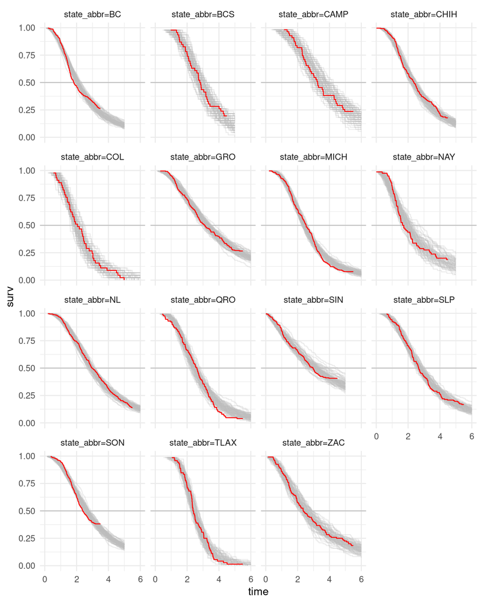

## Evaluación de tamaño de muestra y hora de salida

Ahora simulamos muestras de distintos tamaños, con horas de llegada. Hacemos cortes en distintos tiempos, y **evaluamos en cada hora de salida el sesgo, varianza y error cuadrático medio de los estimadores puntuales**.

```r
# cortes (horas después de 18:30 en la elección de 2018)
cortes <- c(1.5, 2.5, 3, 3.5, 4, 4.5, 5.5, Inf)
# tamaño de muestra
props_muestra <- c(0.05, 0.10, 0.20)
estado_sim <- "NL"
```

[output not shown]

```r
eval_tbl_1 <- map_df(1:400, ~ simular_cortes(.x, cortes= cortes, prop_muestra = 0.03,
                                             estado_sim = estado_sim))
eval_tbl_2 <- map_df(1:400, ~ simular_cortes(.x, cortes= cortes, prop_muestra = 0.05,
                                             estado_sim = estado_sim))
eval_tbl_3 <- map_df(1:400, ~ simular_cortes(.x, cortes= cortes, prop_muestra = 0.10,
                                             estado_sim = estado_sim))
```

En primer lugar, **el error cuadrático medio es menor si se selecciona una muestra inicial más grande**, y se reduce conforme la hora de censura es más tarde:

```
## # A tibble: 3 x 3
##   state_abbr candidato prop_obs
##   <chr>      <chr>        <dbl>
## 1 NL         AMLO_1       0.343
## 2 NL         JAMK_1       0.145
## 3 NL         RAC_1        0.323
```

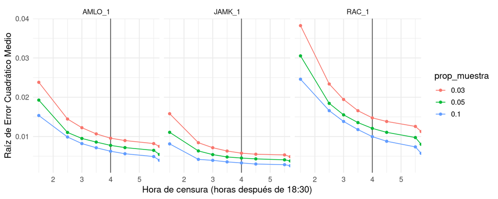

Sin embargo, la **proporción del error que se debe a sesgo es más grande cuanto más grande sea la muestra inicial**:

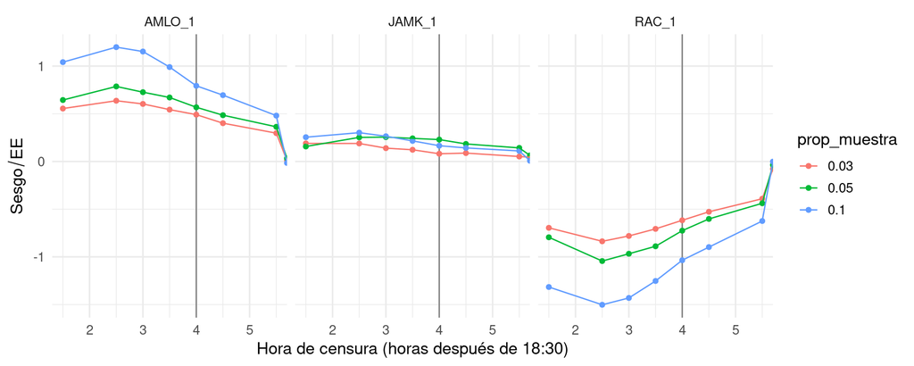

```
## # A tibble: 9 x 5
##   corte prop_muestra candidato     sesgo      ee
##   <dbl> <fct>        <chr>         <dbl>   <dbl>
## 1     4 0.03         AMLO_1     0.00422  0.00859
## 2     4 0.05         AMLO_1     0.00383  0.00674
## 3     4 0.1          AMLO_1     0.00389  0.00490
## 4     4 0.03         JAMK_1     0.000466 0.00575
## 5     4 0.05         JAMK_1     0.00101  0.00441
## 6     4 0.1          JAMK_1     0.000535 0.00323
## 7     4 0.03         RAC_1     -0.00774  0.0126
## 8     4 0.05         RAC_1     -0.00709  0.00978
## 9     4 0.1          RAC_1     -0.00717  0.00693
```

## Puntos de corte y proporción de sesgo: estados de elección 2021

```r
sims_estados <- map_df(estados, function(estado_sim){
  print(estado_sim)
  # simular
  eval_tbl_1 <- map_df(1:400, ~ simular_cortes(.x, cortes= cortes, prop_muestra = 0.03,
                                             estado_sim = estado_sim))
  eval_tbl_2 <- map_df(1:400, ~ simular_cortes(.x, cortes= cortes, prop_muestra = 0.05,
                                             estado_sim = estado_sim))
  eval_tbl_3 <- map_df(1:400, ~ simular_cortes(.x, cortes= cortes, prop_muestra = 0.10,
                                             estado_sim = estado_sim))
  evals_tbl <- bind_rows(eval_tbl_1, eval_tbl_2, eval_tbl_3)

  # proporciones de cómputos
  total <- seleccionar_muestra(conteo, prop = 1, estado_sim)
  prop_obs_tbl <- total %>%
    pivot_longer(cols = all_of(c("AMLO_1", "RAC_1", "JAMK_1")),
               names_to = "candidato", values_to ="num_votos") %>%
    group_by(candidato, state_abbr) %>%
    summarise(acumulado_cand = sum(num_votos),
            acumulado_tot = sum(TOTAL_VOTOS_CALCULADOS),
            .groups = "drop") %>%
    mutate(prop_obs = acumulado_cand / acumulado_tot) %>%
    select(state_abbr, candidato, prop_obs)
  # calcular sesgo, varianza y proporción de muestra.
  ecm_tbl <- evals_tbl %>%
    left_join(prop_obs_tbl, by = "candidato") %>%
    ungroup() %>%
    group_by(corte, prop_muestra, candidato) %>%
    summarise(sesgo = mean(prop_cand) - mean(prop_obs),
            varianza = var(prop_cand),
            prop_casillas_muestra = mean(prop_casillas_muestra),
            .groups = "drop") %>%
    mutate(recm = sqrt(sesgo^2 + varianza)) %>%
    mutate(sesgo_relativo = abs(sesgo) / sqrt(varianza)) %>%
    mutate(prop_muestra = factor(prop_muestra)) %>%
    mutate(state_abbr = estado_sim)
  ecm_tbl
})
```

```
## [1] "ZAC"
## [1] "COL"
## [1] "CHIH"
## [1] "MICH"
## [1] "NAY"
## [1] "BC"
## [1] "BCS"
## [1] "SON"
## [1] "SIN"
## [1] "NL"
## [1] "SLP"
## [1] "QRO"
## [1] "GRO"
## [1] "TLAX"
## [1] "CAMP"
```

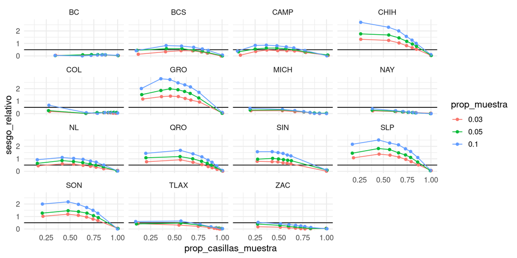

```r
ggplot(sims_estados %>% filter(candidato == "AMLO_1"),
       aes(x = prop_casillas_muestra, y = sesgo_relativo, colour = prop_muestra)) +
  geom_hline(yintercept = 0.5) +
  geom_point() + geom_line() +
  facet_wrap(~state_abbr)
```

## Estimaciones finales vs conteos

**Obs**: las estimaciones de abajo no utilizan la estratificación (corregir).

```r
prop_obs_tbl <- conteo %>%
  pivot_longer(cols = all_of(c("AMLO_1", "RAC_1", "JAMK_1")),
               names_to = "candidato", values_to ="num_votos") %>%
  group_by(candidato, state_abbr) %>%
  summarise(acumulado_cand = sum(num_votos, na.rm = T),
            acumulado_tot = sum(TOTAL_VOTOS_CALCULADOS, na.rm = T),
            num_casillas = n(),
            .groups = "drop") %>%
  mutate(prop_obs = acumulado_cand / acumulado_tot) %>%
  select(state_abbr, candidato, prop_obs, num_casillas)
prop_obs_tbl
```

```
## # A tibble: 96 x 4
##    state_abbr candidato prop_obs num_casillas
##    <chr>      <chr>        <dbl>        <int>
##  1 AGS        AMLO_1       0.396         1598
##  2 BC         AMLO_1       0.639         4701
##  3 BCS        AMLO_1       0.640          977
##  4 CAMP       AMLO_1       0.612         1146
##  5 CDMX       AMLO_1       0.577        12966
##  6 CHIH       AMLO_1       0.430         5286
##  7 CHPS       AMLO_1       0.612         6202
##  8 COAH       AMLO_1       0.444         3761
##  9 COL        AMLO_1       0.578          950
## 10 DGO        AMLO_1       0.464         2458
## # … with 86 more rows
```

```r
prop_muestra_tbl <- llegadas_tbl %>%
  filter(tiempo < 3) %>%
  pivot_longer(cols = all_of(c("AMLO_1", "RAC_1", "JAMK_1")),
               names_to = "candidato", values_to ="num_votos") %>%
  group_by(candidato, state_abbr) %>%
  summarise(acumulado_cand = sum(num_votos, na.rm = T),
            acumulado_tot = sum(TOTAL_VOTOS_CALCULADOS, na.rm = T),
            .groups = "drop") %>%
  mutate(prop_muestra = acumulado_cand / acumulado_tot) %>%
  select(state_abbr, candidato, prop_muestra)
prop_muestra_tbl
```

```
## # A tibble: 96 x 3
##    state_abbr candidato prop_muestra
##    <chr>      <chr>            <dbl>
##  1 AGS        AMLO_1           0.399
##  2 BC         AMLO_1           0.660
##  3 BCS        AMLO_1           0.629
##  4 CAMP       AMLO_1           0.601
##  5 CDMX       AMLO_1           0.576
##  6 CHIH       AMLO_1           0.381
##  7 CHPS       AMLO_1           0.661
##  8 COAH       AMLO_1           0.445
##  9 COL        AMLO_1           0.545
## 10 DGO        AMLO_1           0.487
## # … with 86 more rows
```

```r
comparacion_tbl <- left_join(prop_obs_tbl, prop_muestra_tbl) %>%
  mutate(dif = 100*(prop_muestra - prop_obs)) %>%
  ungroup %>%
  group_by(candidato) %>%
  arrange(candidato, dif) %>%
  mutate(across(is.numeric, ~ round(., 3)))
comparacion_tbl %>%
  DT::datatable()
```

|  | state_abbr | candidato | prop_obs | num_casillas | prop_muestra | dif |
| --- | --- | --- | --- | --- | --- | --- |
| 1 | CHIH | AMLO_1 | 0.43 | 5286 | 0.381 | -4.901 |
| 2 | COL | AMLO_1 | 0.578 | 950 | 0.545 | -3.355 |
| 3 | JAL | AMLO_1 | 0.417 | 9808 | 0.391 | -2.586 |
| 4 | NAY | AMLO_1 | 0.651 | 1668 | 0.626 | -2.487 |
| 5 | YUC | AMLO_1 | 0.391 | 2648 | 0.368 | -2.257 |
| 6 | ZAC | AMLO_1 | 0.48 | 2508 | 0.467 | -1.303 |
| 7 | HGO | AMLO_1 | 0.61 | 3786 | 0.598 | -1.166 |
| 8 | CAMP | AMLO_1 | 0.612 | 1146 | 0.601 | -1.086 |
| 9 | BCS | AMLO_1 | 0.64 | 977 | 0.629 | -1.052 |
| 10 | QRO | AMLO_1 | 0.414 | 2648 | 0.407 | -0.637 |

[output cut: 86 more lines]

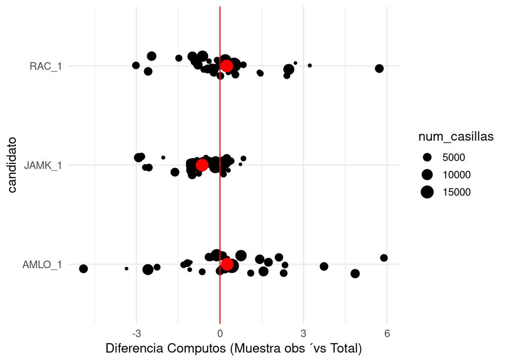

```r
ggplot(comparacion_tbl, aes(x = candidato, y = dif, size = num_casillas)) +
  geom_jitter(width = 0.1, height = 0.0) +
  stat_summary(fun = mean, geom = "point",
               shape = 20, size = 8, color = "red", fill = "red") +
  coord_flip() + geom_hline(yintercept = 0, colour = "red") +
  ylab("Diferencia Computos (Muestra obs ´vs Total)")
```